# Forecasting NZ’s Annual Avocado Yield

### Intermediate Regression Tutorial

**Nick Burns** **Lingo Search & AI**  
**LinkedIn: https://www.linkedin.com/company/lingo-search-ai**

### Regression Models: a powerful tool for augmented intelligence

We are massive fans of regression models here at Lingo Search & AI. There are a lot of myths and misconceptions around regression, such as it cannot capture non-linear trends and is not suitable for more complex datasets. These misconceptions arise through a lack of familiarity with regression techniques, and perhaps too, a lack of training in more advanced regression methods.

But regression models are incredibly powerful. We use them every day to capture structural and functional patterns in the data and to derive robust (and accurate) prediction models. We like that regression methods are transparent, easily interpretable and are a great way to incorporate domain knowledge and human expertise within the model structure itself. They are a great tool towards “augmented intelligence”, where human expertise is supported and enhanced through predictive models which embrace the business domain and which aren’t simply a black box.

### About this tutorial

There is a wealth of machine learning tutorials, blogs and courses online, but it is more challenging to find good learning material for regression models. If you want to dive deeper, our favourite books are:

- Regression and Other Stories (Gelman, Hill and Vehtari)
- Regression Modelling Strategies: With Applications to Linear Models, Logistic Regression, and Survival Analysis (Frank E. Harrell)
- Statistical Rethinking (Richard McElreath)
- Bayesian Data Analysis, BDA3 (Gelman *et. al.*)

In this tutorial, we are going to forecast the annual yield of avocados here in New Zealand. We’ll do this using Stan, and we will incrementally build our model from simple concepts, up to a more complex non-linear mixture model. This isn’t a tutorial in Bayesian stats or Stan. Nor is this a tutorial about regression itself. For more technical material, see the books above. Instead, we will focus on the iterative development process - slowly improving the model, slowly extending the model and improving the predictions. I don’t think there is enough material out there which helps to step people through this iterative workflow - and it is an important part of the modelling precess.

### Avocado Yields in NZ

Avocados are a growing export fruit here in New Zealand. The board reports of [New Zealand Avocado](https://www.nzavocado.co.nz/) are an interesting read, and talk of the “celebrity status” that avocados reached back in 2014. With this surge in popularity of Avocados, both the domestic and export markets have grown exponentially over the last ten years. We’ve trawled through their board reports and extracted the annual yield information going back to approx. 2000. Let’s have a look at this:

```r
library(data.table)
library(ggplot2)
library(rstan)

avo <- fread("../data/Avo_AnnualVolumes_1999-2017.csv")
avo <- avo[Year < 2017]

head(avo)
```

| Year | ExportTrays | LocalMarketTrays | ProcessingTrays | TotalTrays | TotalTonnes |
| --- | --- | --- | --- | --- | --- |
| 1999 | 1125000 | 555000 | 0 | 1680000 | 9400 |
| 2000 | 1400000 | 712000 | 180000 | 2292000 | 12606 |
| 2001 | 1321000 | 678000 | 155000 | 2154000 | 11847 |
| 2002 | 1259000 | 1075000 | 75000 | 2409000 | 13248 |
| 2003 | 1055000 | 825000 | 55000 | 1935000 | 10642 |
| 2004 | 1122175 | 895961 | 118498 | 2136634 | 11751 |

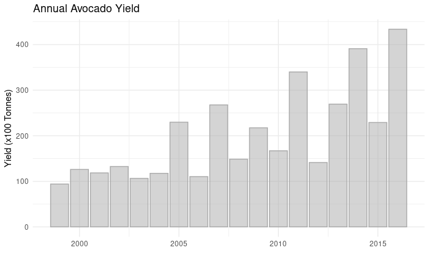

```r
ggplot(avo, aes(x = Year, y = TotalTonnes / 100)) +
  geom_bar(stat="identity", colour="darkgrey", fill = "darkgrey", alpha = 0.5) +
  theme_minimal() +
  ggtitle("Annual Avocado Yield") + xlab("") + ylab("Yield (x100 Tonnes)")
```

We can see that the yields remained relatively flat until approx 2005, at which point they yield started to accelerate. Let’s start to model this.

### Iteration One: Simple linear long-term trend

At first glance, the growth from 2005 onwards seems reasonably steady. The simplest model we could have for this is a linear growth trend:

$$yield \sim Normal(\mu, \sigma) \\
\mu = \alpha + \beta.year \\
\alpha \sim Normal(50, 25) \\
\beta \sim Normal(0, 20) \\
\sigma \sim HalfNormal(0, 5)$$

Let’s fit this using stan, and plot the results:

```r
fit <- stan(
  "../stan/avo/linear_growth.stan",
  data = list('N' = nrow(avo), yield = avo$TotalTonnes / 100, 'year' = 1:nrow(avo)),
  chains = 1
)
round(summary(fit)$summary[1:4, ], 3)
```

```
          mean se_mean     sd   2.5%    25%    50%    75%   97.5%   n_eff  Rhat
alpha   59.474   0.611 13.682 31.840 49.973 59.002 68.943  85.445 501.801 0.999
beta    14.940   0.059  1.333 12.430 14.038 14.901 15.823  17.594 513.618 1.002
sigma   34.946   0.097  2.331 30.732 33.323 34.882 36.461  39.665 574.178 0.999
yhat[1] 74.199   1.330 36.901  0.454 50.026 74.895 99.458 144.191 769.482 1.000
```

We have no warnings from stan, which is a positive sign. The `Rhat` and `n_eff` are reasonable. Let’s look at the results:

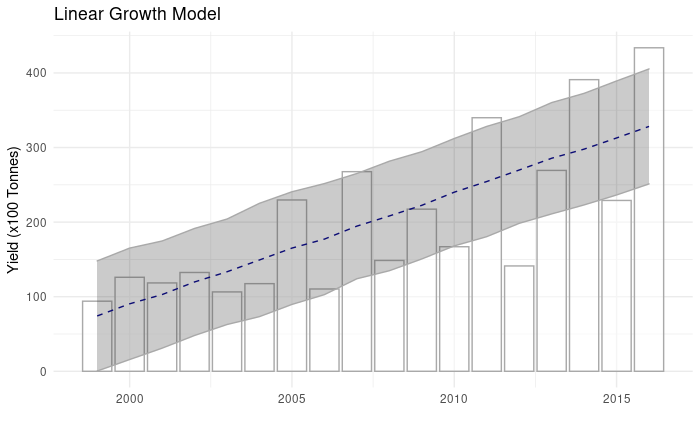

```r
yhats <- extract(fit)$yhat
avo[, linear_growth := colMeans(yhats)]

ggplot(avo, aes(x = Year, y = TotalTonnes / 100)) +
  geom_bar(stat="identity", colour="darkgrey", fill='white', alpha = 0.5) +
  geom_line(aes(y = linear_growth), colour = 'darkblue', linetype='dashed') +
  geom_ribbon(aes(ymin = linear_growth - 2*apply(yhats, 2, sd), ymax = linear_growth + 2*apply(yhats, 2, sd)),
              colour = 'darkgrey', alpha=0.25) +
  theme_minimal() +
  ggtitle("Linear Growth Model") + xlab("") + ylab("Yield (x100 Tonnes)")
```

This linear trend is about as simple as we can conceive for this data. The results aren’t terrible - they are sensible. However, the uncertainty intervals are high, and it doesn’t look like we are capturing much of the detail in the yield curve.

### Iteration Two: Saturated Growth

One of the first things that jump out at me here, is that assuming that the growth will continue to grow linearly forever is a little too simplistic. New Zealand is a small country, and avocado has to compete with our larger exports (beef, lamb and dairy) for space. It seems more likely that there will be a cap, an upper limit, to the amount of avocado produced each year. So, for our second iteration, let’s refactor the model so that future yields follow a saturating growth curve.

Our second model will be:

$$yield \sim Normal(\mu, \sigma) \\
\mu = \alpha + \beta.log(year) \\
\alpha \sim Normal(50, 25) \\
\beta \sim Normal(0, 20) \\
\sigma \sim HalfNormal(0, 5)$$

We’ll use the same stan model as before, but simply log-transform the year feature:

```r
fit <- stan(
  "../stan/avo/linear_growth.stan",
  data = list('N' = nrow(avo), yield = avo$TotalTonnes / 100, 'year' = log2(1:nrow(avo))),
  chains = 1
)
round(summary(fit)$summary[1:4, ], 3)
```

```
          mean se_mean     sd    2.5%    25%    50%    75%   97.5%   n_eff  Rhat
alpha   53.581   0.951 17.660  17.515 41.731 52.821 66.337  86.586 344.862 1.000
beta    50.969   0.290  6.025  39.361 46.849 50.911 55.232  62.520 431.310 0.999
sigma   37.925   0.115  2.279  33.949 36.388 37.747 39.420  42.711 395.637 0.999
yhat[1] 52.158   1.591 42.091 -32.040 24.451 52.825 80.810 132.121 699.833 0.999
```

Again, we have no warnings from stan, which is a positive sign. The `Rhat` and `n_eff` are reasonable. Let’s look at the results:

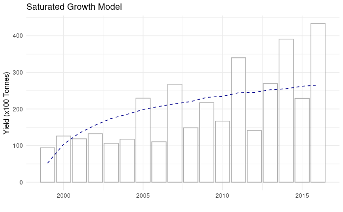

```r
yhats <- extract(fit)$yhat
avo[, linear_growth := colMeans(yhats)]

ggplot(avo, aes(x = Year, y = TotalTonnes / 100)) +
  geom_bar(stat="identity", colour="darkgrey", fill='white', alpha = 0.5) +
  geom_line(aes(y = linear_growth), colour = 'darkblue', linetype='dashed') +
  theme_minimal() +
  ggtitle("Saturated Growth Model") + xlab("") + ylab("Yield (x100 Tonnes)")
```

Our prediction model now shows a saturating growth curve - which is great! This is some “domain knowledge” that we want our model to incorporate. However, the fit doesn’t look quite as ‘reasonable’ as before: it’s too high at the start, it’s too low at the end, and the residual error is higher. From a pure “accuracy” perspective this is a backwards step. But the saturating fit is a domain constraint that we must keep… so what next?

### Iteration Three: Bienniel Model

Knowing a little more about avocado production might just help us… Avocado is a biennial fruit. It tends to have a bumper crop one year followed by a smaller crop on the off years. We can see this in the historical yields too, with bumper crops evident in 2005, 2007, 2009, 2011, 2014 and 2016.

Note however, that this pattern isn’t strictly alternating. It will be impacted by weather and influenced by the maturing of new avocado orchards. So we can’t simply add an alternating indicator variable for this.

This is where our Bayesian approach will start to shine. Using stan, we can define our model as a mixture model. In this case, it will be a mixture with 2 components, one for the bumper years and one for the smaller yields. We don’t need to identify these in the data, we will let the model choose the most appropriate mixture given the data.

Again, this is a reasonably small extension to our previous model:

$$yield \sim Normal(\mu_i, \sigma) \\
\mu_i = \alpha_i + \beta_i.log(year) \\
\alpha_i \sim Normal(50, 25) \\
\beta_i \sim Normal(0, 20) \\
\sigma \sim HalfNormal(0, 5) \\
\\
\\
where \ i \begin{cases}
1, & if \ bumper \ year \\
0, & otherwise
\end{cases}$$

Check out the stan file if you’re interested in the stan code for this. We’ll fit and inspect the results:

```r
fit <- stan(
  "../stan/avo/biennial_model.stan",
  data = list('N' = nrow(avo), yield = avo$TotalTonnes / 100, 'year' = log2(1:nrow(avo))),
  chains = 1
)
round(summary(fit)$summary[1:6, ], 3)
```

```
           mean se_mean     sd   2.5%    25%    50%    75%  97.5%    n_eff  Rhat
alpha[1] 52.928   0.568 16.540 19.800 42.099 52.321 63.532 85.067  848.888 0.999
alpha[2] 51.064   0.916 22.490 10.682 33.942 51.302 65.836 98.100  602.258 0.999
beta[1]  51.173   0.192  5.635 40.191 47.245 51.135 54.945 62.580  865.572 1.001
beta[2]  16.822   0.404 12.575  0.925  7.096 14.318 23.754 47.338  968.761 1.004
lambda    0.497   0.003  0.108  0.295  0.422  0.493  0.571  0.722 1195.458 1.001
sigma    37.764   0.076  2.370 33.266 36.109 37.615 39.277 42.652  969.138 1.001
```

Again, we have no warnings from stan, which is a positive sign. The `Rhat` and `n_eff` are reasonable. Let’s look at the results:

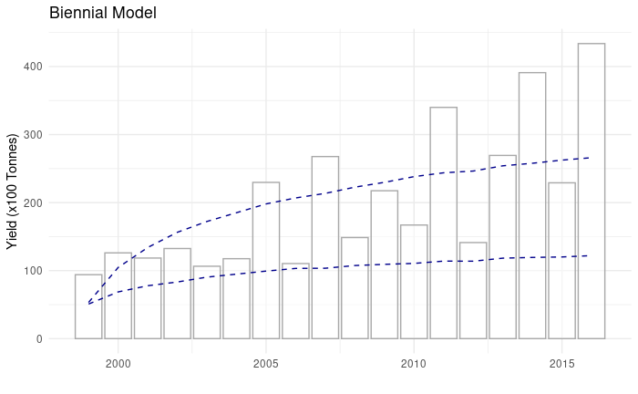

```r
yhats <- extract(fit)$yhat
avo[, bumper_growth := colMeans(yhats[,,1])]
avo[, normal_growth := colMeans(yhats[,,2])]

g1 <- ggplot(avo, aes(x = Year, y = TotalTonnes / 100)) +
  geom_bar(stat="identity", colour="darkgrey", fill='white', alpha = 0.5) +
  geom_line(aes(y = bumper_growth), colour = 'darkblue', linetype='dashed') +
  geom_line(aes(y = normal_growth), colour = 'darkblue', linetype='dashed') +
  theme_minimal() +
  ggtitle("Biennial Model") + xlab("") + ylab("Yield (x100 Tonnes)")

g2 <- ggplot(avo, aes(x = Year, y = TotalTonnes / 100)) +
  geom_bar(stat="identity", colour="darkgrey", fill='white', alpha = 0.5) +
  geom_line(aes(y = bumper_growth), colour = 'darkblue', linetype='dashed') +
  geom_line(aes(y = normal_growth), colour = 'darkblue', linetype='dashed') +
  geom_ribbon(aes(ymin = bumper_growth - 2*apply(yhats[,,1], 2, sd), ymax = bumper_growth + 2*apply(yhats[,,1], 2, sd)),
              colour = 'darkgrey', alpha=0.25) +
  geom_ribbon(aes(ymin = normal_growth - 2*apply(yhats[,,2], 2, sd), ymax = normal_growth + 2*apply(yhats[,,2], 2, sd)),
              colour = 'darkgrey', alpha=0.25) +
  theme_minimal() +
  ggtitle("Biennial Model") + xlab("") + ylab("Yield (x100 Tonnes)")

g1
```

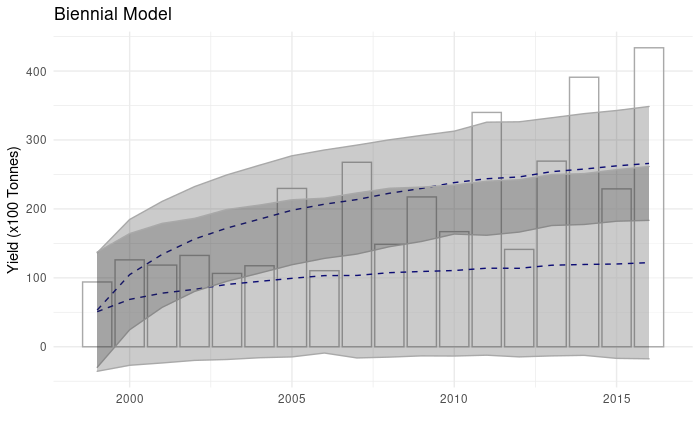

```r
g2
```

The good news, is that we have a model now which respects the biennial pattern of avocado and which also incorporates the domain constraint of saturating growth. This sounds good… the model is a reflection of our domain knowledge. However, the fit is poor:

- the bumper year forecasts aren’t too bad.
- the normal years are too low.
- the uncertainty in these is enormous.

This isn’t good.

At this point, there might be a temptation to throw this model out and start again. Perhaps you might be tempted to change direction entirely and throw this at a random forest or a neural network - this data is clearly nonlinear and a challenge to model after all! But that would be an extreme reaction, and it may not actually help you solve your problem…

The questions to ask at this point are:

- where does this model struggle?
- What areas of the data does the model struggle to describe?
- Why might this be the case?

Simply throwing the data at another algorithm would be a mistake - it won’t help you start to explore these questions and develop a more robust model. You might get lucky… but it probably won’t be a good model, and it will almost certainly result in throwing away the domain knowledge that you definitely want to keep. So then… what next?

### Iteration Four: Extended Biennial Model

Let’s look at the fit above. Where does the model struggle? I see a couple of things here:

1. The normal years seem to be too flat…
2. The model does a very poor job of fitting the early years (prior to ~2005). You can see this, with the steep climb in the bumper model (which isn’t reflected in the data) and these initial years are also flattening the model of the normal years.

We need a more detailed model, one that can capture and account for the earlier trends prior to 2005.

Let’s have a look at a loess-fit to the data, to get a sense of what might be a little more sensible:

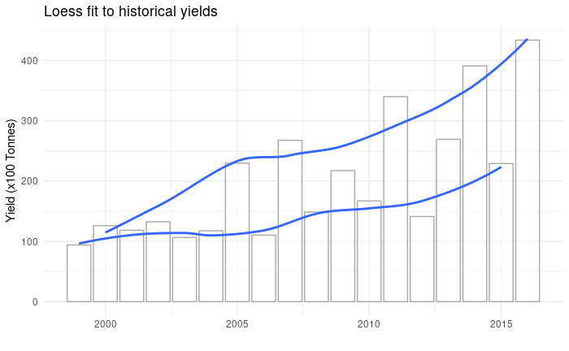

```r
avo[, bumper_indicator := 1]
avo[Year %in% c(1999, 2001, 2003, 2004, 2006, 2008, 2010, 2012, 2015), bumper_indicator := 0]

ggplot(avo, aes(x = Year, y = TotalTonnes / 100)) +
  geom_bar(stat="identity", colour="darkgrey", fill='white', alpha = 0.5) +
  geom_smooth(aes(group = factor(bumper_indicator)), se = FALSE) +
  theme_minimal() +
  ggtitle("Loess fit to historical yields") + xlab("") + ylab("Yield (x100 Tonnes)")
```

The loess curves here follow the historical data quite nicely, and what we see here is that the growth is more exponential than logarithmic. This aligns well to the domain knowledge too, where New Zealand Avocado’s board reports talk of a dramatic rise in the popularity of avocados and a steep rise in both domestic and export demand.

However, an unconstrained exponential model would lead to exploding forecasts into the future which is not consistent with our domain constraint and knowledge. So what to do?

You might be tempted to start to factor in demand forecasts. However, in this case, I think that would be a mistake. Demand is correlated with supply (yield) but it is not causally related. There will always be an upper limit to how much avocado NZ farms can produce, regardless of demand. We’ve seen that when demand outstrips supply, prices sky rocket. So this isn’t the solution.

Instead, let’s tweak our growth model so that it follows more of a sigmoidal shape (i.e. an S-shape). Sounds fancy? It’s not really. This is a pretty typical natural growth curve, where a species’ growth is initially exponentially, but then flattens out again due to natural constraints (perhpas due to a lack of food, or space, or the growth in predator numbers).

We are going to use the following form of a “sigmoidal” growth curve:

$$growth = \gamma \frac{1 + exp(\beta\eta)}{1 + exp(\beta (\eta - year))}$$

$\beta$ and $\eta$ control the center and slope of the curve. $\gamma$ controls the magnitude of the curve. We’re going to stick with our biennial mixture model as well, so we would expect $\gamma$ to be larger for the bumper year model than the model for the normal years.

Our yield model will now be:

$$yield \sim Normal(\mu_i, \sigma) \\
\mu_i = \alpha + growth_i \\ \ \\
growth_i = \gamma_i \frac{1 + exp(\beta\eta)}{1 + exp(\beta (\eta - year_i))} \\ \ \\
\alpha \sim Normal(0, 10) \\
\beta \sim Normal(0, 5) \\
\eta \sim Normal(0, 5) \\
\gamma_i \sim Normal(0, 5) \\
\sigma \sim HalfNormal(0, 5) \\
\\
\ \\
where \ i \begin{cases}
1, & if \ bumper \ year \\
0, & otherwise
\end{cases}$$
As before, this is a mixture model. The mixture model assumes the same growth model for both mixtures, except for the magnitude parameter. This looks more complex, but isn’t too difficult to code in stan (see the stan file).

Let’s fit this and inspect the results:

```r
round(summary(fit)$summary[1:8, ], 3)
```

[output not shown]

```
            mean se_mean     sd    2.5%    25%    50%    75%  97.5%   n_eff  Rhat
alpha     29.699   0.398  9.661  10.286 23.514 29.764 36.068 48.423 588.446 0.999
beta       0.454   0.002  0.050   0.368  0.421  0.450  0.482  0.561 533.841 1.001
eta        7.296   0.026  0.630   6.054  6.888  7.305  7.710  8.538 577.888 0.999
gamma[1]   6.747   0.077  1.752   3.584  5.551  6.682  7.867 10.536 524.122 1.005
gamma[2]  13.678   0.146  3.343   7.540 11.296 13.727 15.835 20.552 523.974 1.004
lambda     0.494   0.004  0.088   0.332  0.432  0.494  0.555  0.664 565.749 1.005
sigma     25.636   0.104  2.565  20.914 23.739 25.517 27.450 30.713 603.185 0.999
yhat[1,1] 39.975   0.945 27.526 -16.378 21.032 39.465 59.323 93.083 849.284 0.999
```

Let’s look at the fit:

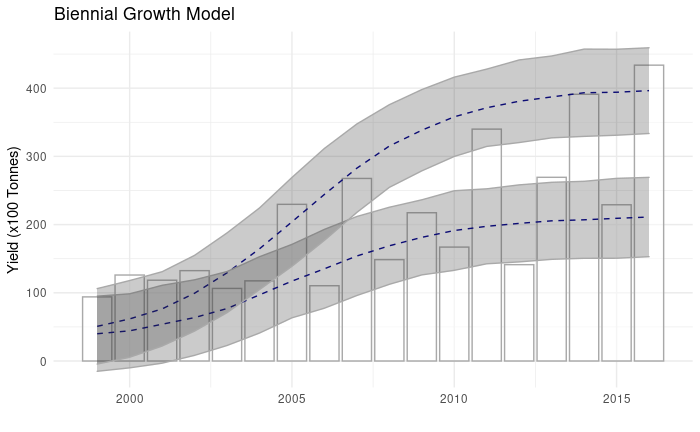

```r
yhats <- extract(fit)$yhat
avo[, bumper_growth := colMeans(yhats[,,1])]
avo[, normal_growth := colMeans(yhats[,,2])]

ggplot(avo, aes(x = Year, y = TotalTonnes / 100)) +
  geom_bar(stat="identity", colour="darkgrey", fill='white', alpha = 0.5) +
  geom_line(aes(y = bumper_growth), colour = 'darkblue', linetype='dashed') +
  geom_line(aes(y = normal_growth), colour = 'darkblue', linetype='dashed') +
  geom_ribbon(aes(ymin = bumper_growth - 2*apply(yhats[,,1], 2, sd), ymax = bumper_growth + 2*apply(yhats[,,1], 2, sd)),
              colour = 'darkgrey', alpha=0.25) +
  geom_ribbon(aes(ymin = normal_growth - 2*apply(yhats[,,2], 2, sd), ymax = normal_growth + 2*apply(yhats[,,2], 2, sd)),
              colour = 'darkgrey', alpha=0.25) +
  theme_minimal() +
  ggtitle("Biennial Growth Model") + xlab("") + ylab("Yield (x100 Tonnes)")
```

This is a massive improvement. We’ve now got two mixtures, one for the bumper years and one for the “normal” years which fit the data well and which still respect our domain constraints and expertise. This is really promising.

### Iteration Five: Refining the final model

This appears to be a good working model. The only thing left is to refine it. We are going to:

- allow for more long-term growth, by adding a long-term linear growth term to this model
- allow a little more flexibility in the mixture model, allowing for varying long-term growth as well as verying magnitude

Our final, refined model will be:

$$yield \sim Normal(\mu_i, \sigma_i) \\
\mu_i = trend_i + growth_i \\ \ \\
trend_i = \alpha + \rho_i(\delta_i - year_i) \\
growth_i = \gamma_i \frac{1 + exp(\beta\eta)}{1 + exp(\beta (\eta - year_i))} \\ \ \\ \ \\
\alpha \sim Normal(0, 10) \\
\rho_i \sim Normal(0, 5) \\
\delta_i \sim Normal(0, 5) \\
\beta \sim Normal(0, 5) \\
\eta \sim Normal(0, 5) \\
\gamma_i \sim Normal(0, 5) \\
\sigma_i \sim HalfNormal(0, 5) \\ \ \\
where \ i \begin{cases}
1, & if \ bumper \ year \\
0, & otherwise
\end{cases}$$
Again, this is starting to look quite complex. But the journey to this final model has been a slow, incremental task where we’ve added a little more complexity at each step.

As before, we’ll fit this in stan and look at the results. The chains sample nice and quickly, so we’ll increase the length of the chain.

```r
fit <- stan(
  "../stan/avo/final_model.stan",
  data = list('N' = nrow(avo), yield = avo$TotalTonnes / 100, 'year' = 1:nrow(avo)),
  chains = 1, iter = 10000, warmup = 2000
)
round(summary(fit)$summary[1:16, ], 3)
```

```
             mean se_mean     sd   2.5%     25%     50%     75%   97.5%    n_eff  Rhat
alpha      63.885   0.365 16.541 27.943  53.333  65.519  75.847  92.095 2050.031 1.000
rho[1]      4.128   0.157  3.310  0.118   1.543   3.333   5.823  12.251  443.262 1.000
rho[2]      3.107   0.069  2.441  0.107   1.138   2.532   4.584   8.971 1249.147 1.000
delta[1]    9.155   0.207  4.948  0.565   5.413   8.899  12.745  18.937  571.501 1.000
delta[2]    5.544   0.102  3.608  0.258   2.622   5.106   8.016  13.278 1261.568 1.000
beta        0.372   0.002  0.045  0.281   0.344   0.374   0.402   0.459  604.292 1.001
eta         9.335   0.070  1.313  7.748   8.479   8.935   9.644  12.683  349.907 1.001
gamma[1]   12.712   0.062  3.263  6.764  10.427  12.614  14.831  19.573 2779.230 1.000
gamma[2]    6.432   0.035  1.897  3.159   5.113   6.266   7.614  10.585 2956.217 1.000
lambda      0.455   0.002  0.090  0.284   0.392   0.455   0.518   0.631 2199.673 1.000
sigma[1]   14.605   0.118  3.193  8.077  12.583  14.672  16.698  20.887  728.199 1.002
sigma[2]   21.437   0.032  2.309 17.370  19.783  21.320  22.905  26.336 5194.788 1.000
yhat[1,1] 125.585   2.542 47.849 65.855  95.279 110.858 134.931 245.359  354.325 1.000
yhat[1,2]  89.242   0.697 28.055 33.934  70.334  89.348 107.934 143.760 1618.078 1.000
yhat[2,1] 129.122   2.346 44.372 72.621 100.710 116.136 138.438 239.352  357.731 1.001
yhat[2,2]  89.920   0.593 27.481 35.302  71.698  89.878 108.152 143.398 2149.701 1.000
```

And we’ll look at our final fit:

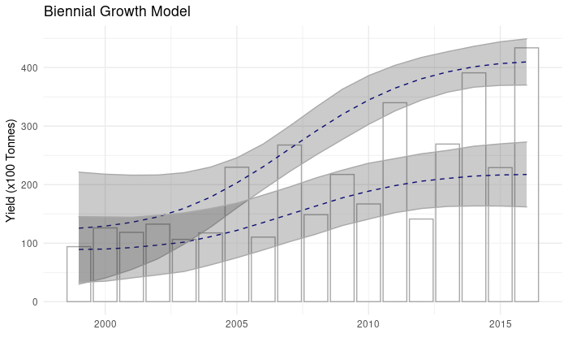

```r
yhats <- extract(fit)$yhat
avo[, bumper_growth := colMeans(yhats[,,1])]
avo[, normal_growth := colMeans(yhats[,,2])]

ggplot(avo, aes(x = Year, y = TotalTonnes / 100)) +
  geom_bar(stat="identity", colour="darkgrey", fill='white', alpha = 0.5) +
  geom_line(aes(y = bumper_growth), colour = 'darkblue', linetype='dashed') +
  geom_line(aes(y = normal_growth), colour = 'darkblue', linetype='dashed') +
  geom_ribbon(aes(ymin = bumper_growth - 2*apply(yhats[,,1], 2, sd), ymax = bumper_growth + 2*apply(yhats[,,1], 2, sd)),
              colour = 'darkgrey', alpha=0.25) +
  geom_ribbon(aes(ymin = normal_growth - 2*apply(yhats[,,2], 2, sd), ymax = normal_growth + 2*apply(yhats[,,2], 2, sd)),
              colour = 'darkgrey', alpha=0.25) +
  theme_minimal() +
  ggtitle("Biennial Growth Model") + xlab("") + ylab("Yield (x100 Tonnes)")
```

### Final Thoughts

This final model is looking fantastic. Getting here was a bit of a journey - and this undeniably takes time. But look at what we have got for the effort. We have a model which:

- respects the domain knowledge, and therefore can reliably be used in an “augmented intelligence” setting
- reflects the surge in popularity in avocados which were a major focus of the annual board reports from 2007 onwards
- is constrained by an reasonable upper ceiling to the yields
- handles the early years prior to 2005
- accounts for both bumper crops and normal crops
- is 100% transparent, interpretable and accurate
- we’ve done all of this with very little data… nice!

Could we go further? Yes, we probably could. In particular, the “future growth”, or the long-term trend model could benefit from more domain knowledge and incorporating some of the business’ projections. But for now, I’m pretty happy wiht this.